# Exploratory Data Analysis in R

Tuesday, August 28th, 2018

## Introduction

1. The Data Science Process
2. The Case
3. The Tidyverse

## My Third Favorite Picture:

[figure not shown]

- **Exploratory data analysis (EDA)** covers roughly the "transform" and "visualize" steps.

## EDA is…

## …getting to know your Data

[figure not shown]

## What We'll Do This Morning

- Ask an impactful question of a real data set.
- Use EDA to propose candidate answers.
- Create a simple business intelligence (BI) [dashboard](https://philchodrow.github.io/mban_orientation/data_science_intro/wrangle_viz/dashboard.html) to guide decision-makers.

## The Case

## The Case

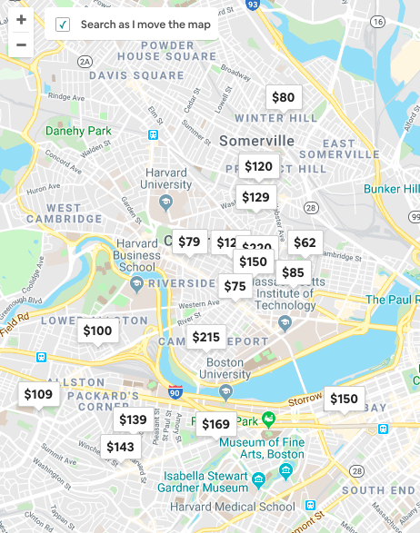

- AirBnB can maximize its business by ensuring a strong supply of diverse hosts in various neighborhoods.
- Their question for you: *Where should we recruit more hosts?*
- They have given you a complex, multi-part data set to study using `R`!

## FYI: Base `R` and the Tidyverse

- You can do EDA in "base" `R` without any packages.
- But base `R` is a bad programming language.
- We will use the **Tidyverse**, a set of packages that promote code which is easy to **write** and **read**, highly **performant**, and **consistent** through the data scientific pipeline.
- The Tidyverse has been extensively developed by **Hadley Wickham** and collaborators over the last decade.

If you have prior experience in `R` and did not begin all your scripts with `library(dplyr)`….

## FYI: Base `R` and the Tidyverse

[figure not shown]

## Getting Started

1. Data Import and Inspection
2. Data Subsetting
3. The Pipe
4. Exercises

## Pipes for your Data

[figure not shown]

## Pipes for your Data

[figure not shown]

- `x %>% f()` \(\Longleftrightarrow\) `f(x)`
- *"Take `x`, and **then** do `f` to it"*
- `x %>% f(y)` \(\Longleftrightarrow\) `f(x,y)`
- `x %>% f(y) %>% g(z)` \(\Longleftrightarrow\) `g(f(x,y),z)`
- *"Take `x`, **then** do `f` with option `y`, **then** do `g` with option `z`…"*

## Some Simple Examples

```r
# familiar
listings %>% glimpse()  # = glimpse(listings)
listings %>% head()     # = head(listings)
listings %>% colnames() # = colnames(listings)

# get all columns with "review_scores" in the column name
listings %>% select(contains('review_scores'))
# what should this return?
listings %>% select(contains('review_scores')) %>% colnames()
# compare: colnames(select(listings, contains('review_scores')))
```

Let's try this out – back to the case study!

## Summarising Data

1. Summary Statistics
2. Adding Columns
3. Grouping

## Data Summaries

- You should usually summarise your data before turning on the fancy algorithms – sometimes the story is clear.

[figure not shown]

## Basic Data Summaries

Go from this:

| id | neighbourhood_cleansed | review_scores_rating |
| --- | --- | --- |
| 12147973 | Roslindale | NA |
| 3075044 | Roslindale | 94 |
| 6976 | Roslindale | 98 |
| 1436513 | Roslindale | 100 |
| 7651065 | Roslindale | 99 |
| 12386020 | Roslindale | 100 |

## Basic Data Summaries

…to this:

| neighbourhood_cleansed | n | mean_rating |
| --- | --- | --- |
| Leather District | 5 | 98.33333 |
| Roslindale | 56 | 95.38000 |
| West Roxbury | 46 | 95.21212 |
| South Boston Waterfront | 83 | 94.43103 |
| Jamaica Plain | 343 | 94.15932 |
| Longwood Medical Area | 9 | 94.00000 |

## Summaries the Tidy Way

- `data %>% mutate(new_col = formula(old_col1, old_col2)` creates new columns.
- `data %>% group_by(col)` groups data for breakout summaries.
- `data %>% summarise(measure = formula(col1, col2))` computes summaries.
- `data %>% group_by(col) %>% summarise(measure = formula(col1, col2))` computes breakout summaries.
- Let's test these out in the case study.

## Keeping Current

1. More practice with `filter` and `summarise`
2. `join`ing data

## How Recent is our Info?

```r
calendar %>%
    summarise(earliest = min(date),
              latest = max(date))
```

```
## # A tibble: 1 x 2
##   earliest   latest
##   <date>     <date>
## 1 2016-09-06 2017-09-05
```

But some of these listings may be "zombies" without recent availability. How can we include only listings with availability from a certain time period?

## The Approach

1. Operate on the `calendar` table (exercise)
2. `join` that information to the `listings` table (together)
3. Filter the listings table accordingly (together)

## Relational Data

The information we need is distributed between two tables – how can we get there?

We need a **key** column that tells us which `calendar` rows correspond to which `listings`.

> `listings$id` corresponds to `calendar_listing$id`

## `join`

The `join` family of functions lets us add columns from one table to another using a key.

We'll use `left_join` for this case – let's try it in the case study.

## Getting Visual

1. Graphical Excellence
2. The Grammar of Graphics
3. `ggplot2`

## My Third Favorite Picture:

[figure not shown]

## Graphical Excellence

[figure not shown]

## Graphical Excellence

> Graphical excellence is the **well-designed presentation of interesting data** – a matter of substance, of statistics, and of design. Graphical excellence consists of complex ideas communicated with **clarity**, **precision**, and **efficiency**.

– *Edward Tufte*

## Graphical Excellence

[figure not shown]

## The Grammar of Graphics

A **grammar** is a set of components (ingredients) that you can combine to create complex structures (sentences, recipes, data visualizations). In baking….

- **A body** – typically some kind of flour)
- **Binder** – eggs, oil, butter, applesauce
- **A rising agent** – yeast, baking soda, baking powder
- **Flavoring** – sugar, salt, chocolate, vanilla

[figure not shown]

## The Grammar of Graphics

- Puts the `gg` in `ggplot2`.
- Formulated by Leland Wilkinson.
- Implemented in code by Hadley Wickham, now part of the `tidyverse`

[figure not shown]

## Ingredients of a data visualization

- **`Data`**: almost always a `data_frame`
- **`Aes`**thetic mapping: relation of data to chart components.
- **`Geom`**etry: specific visualization type? E.g. line, bar, heatmap?
- **`Stat`**istical transformation: how should the data be transformed or aggregated before visualizing?
- **`Theme`**: how should the non-data parts of the plot look?
- Misc. other options.
- (`+` plays the same role in `ggplot2` that `%>%` does in data manipulation.)

## First Plot

Does getting **lots** of reviews usually mean you get **good** reviews?

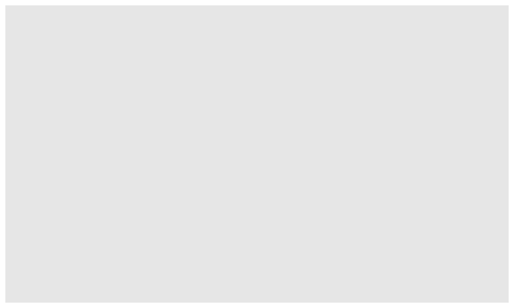

```r
listings %>%
    ggplot()
```

## First Plot

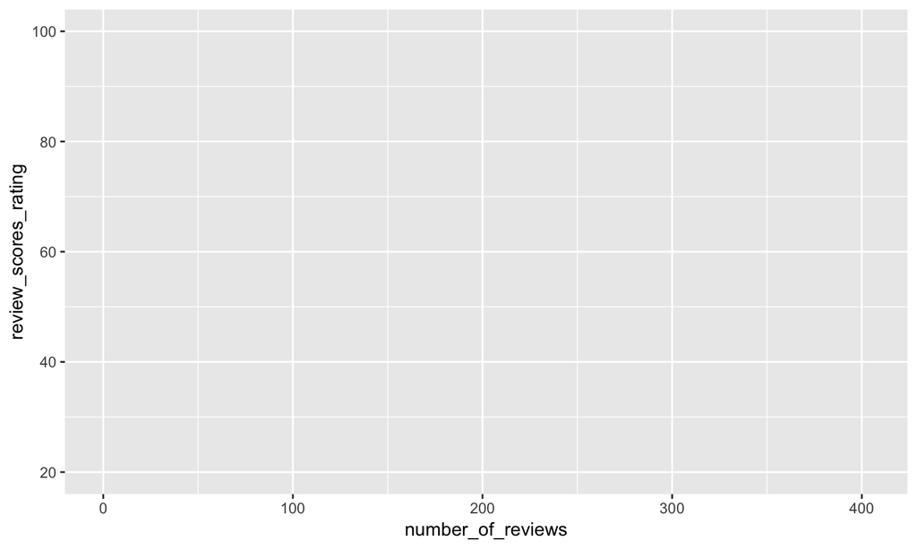

```r
listings %>%
    ggplot() +
    aes(x = number_of_reviews, y = review_scores_rating)
```

## First Plot

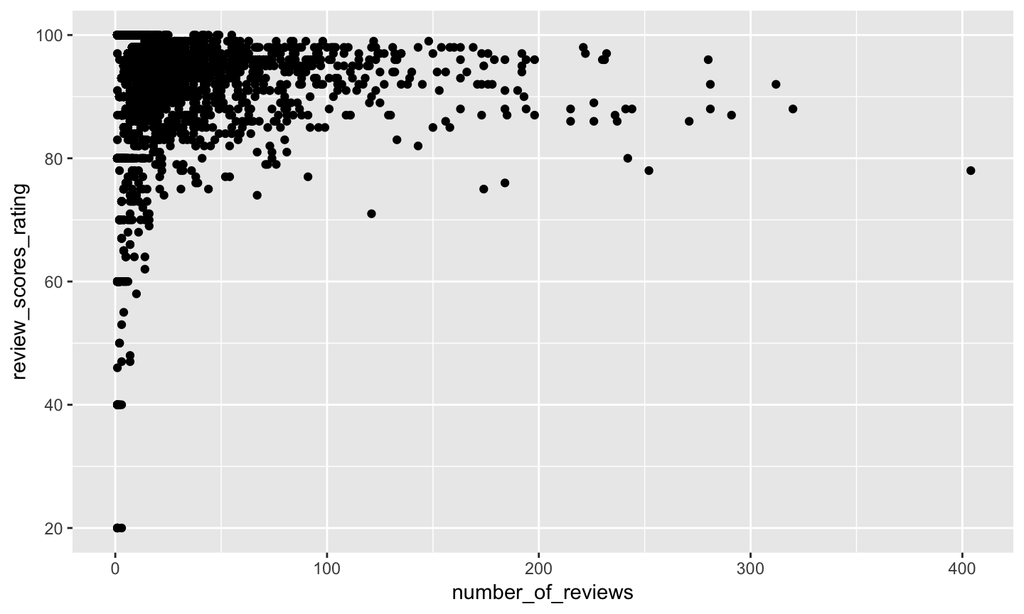

```r
listings %>%
    ggplot() +
    aes(x = number_of_reviews, y = review_scores_rating) +
    geom_point()
```

## First Plot

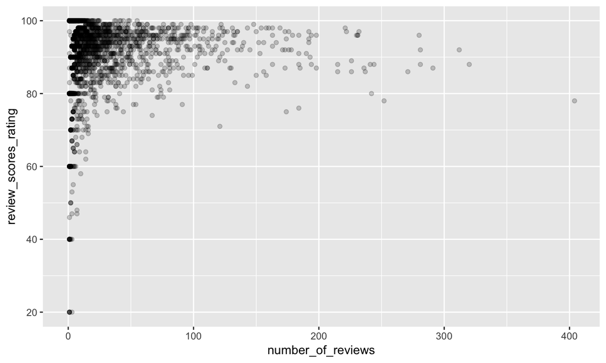

```r
listings %>%
    ggplot() +
    aes(x = number_of_reviews, y = review_scores_rating) +
    geom_point(alpha = .2)
```

## First Plot

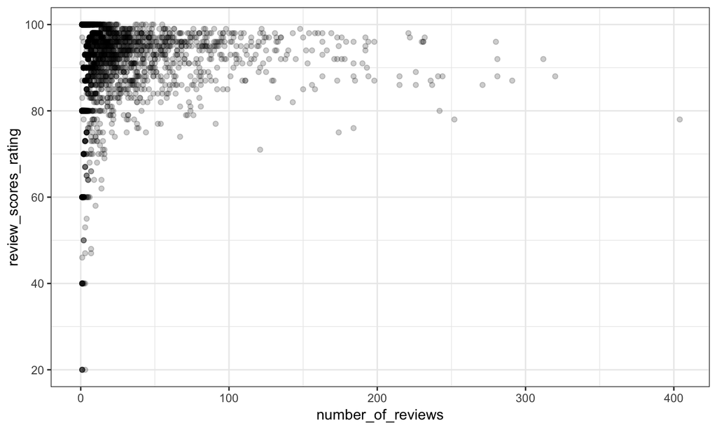

```r
listings %>%
    ggplot() +
    aes(x = number_of_reviews, y = review_scores_rating) +
    geom_point(alpha = .2) +
    theme_bw()
```

## First Plot

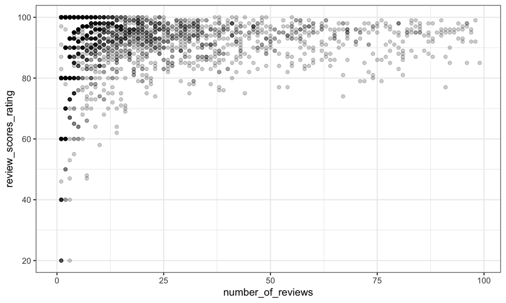

```r
listings %>%
    filter(number_of_reviews < 100) %>%
    ggplot() +
    aes(x = number_of_reviews, y = review_scores_rating) +
    geom_point(alpha = .2) +
    theme_bw()
```

## First Plot

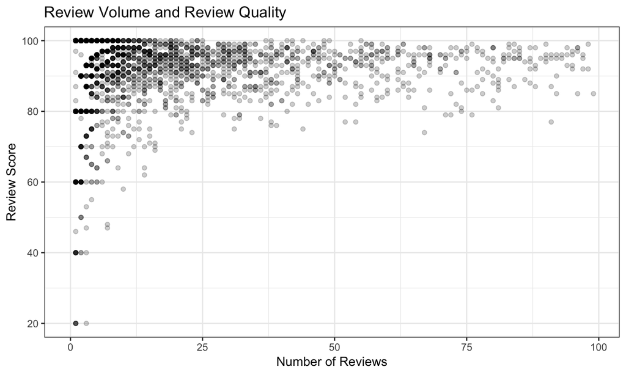

```r
listings %>%
    filter(number_of_reviews < 100) %>%
    ggplot() +
    aes(x = number_of_reviews, y = review_scores_rating) +
    geom_point(alpha = .2) +
    theme_bw() +
    labs(x='Number of Reviews', y='Review Score', title='Review Volume and Review Quality')
```

## First Plot

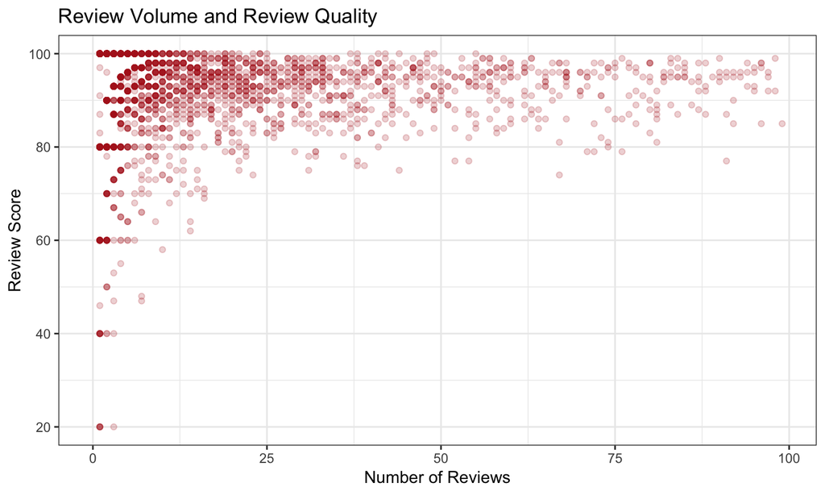

```r
listings %>%
    filter(number_of_reviews < 100) %>%
    ggplot() +
    aes(x = number_of_reviews, y = review_scores_rating) +
    geom_point(alpha = .2, color = 'firebrick') +
    theme_bw() +
    labs(x='Number of Reviews', y='Review Score',title='Review Volume and Review Quality')
```

## Changing Aesthetics

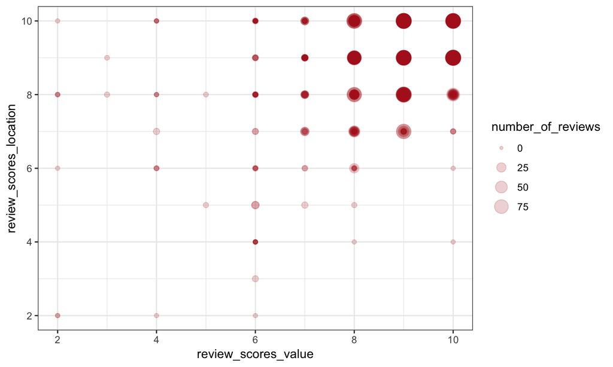

```r
listings %>%
    filter(number_of_reviews < 100) %>%
    ggplot() +
    aes(x = review_scores_value,
        y = review_scores_location,
        size = number_of_reviews) +
    geom_point(alpha = .2, color = 'firebrick') +
    theme_bw()
```

## As a Heatmap

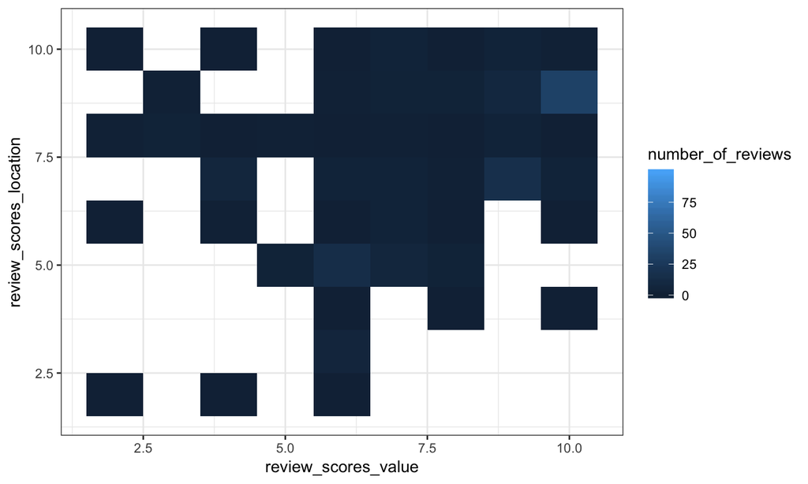

```r
listings %>%
    filter(number_of_reviews < 100) %>%
    ggplot() +
    aes(x = review_scores_value,
        y = review_scores_location,
        fill = number_of_reviews) +
    geom_tile() +
    theme_bw()
```

## Exercise 6

The following code computes the average price of all listings on each day in the data set:

```r
average_price_table <- calendar %>%
    mutate(price = price %>% gsub('\\$|,', '',.) %>% as.numeric()) %>%
    group_by(date) %>%
    summarise(mean_price = mean(price, na.rm = TRUE))
```

Use `geom_line()` to visualize these prices with time on the `x`-axis and price on the `y`-axis.

## Exercise 6 Sample Solution

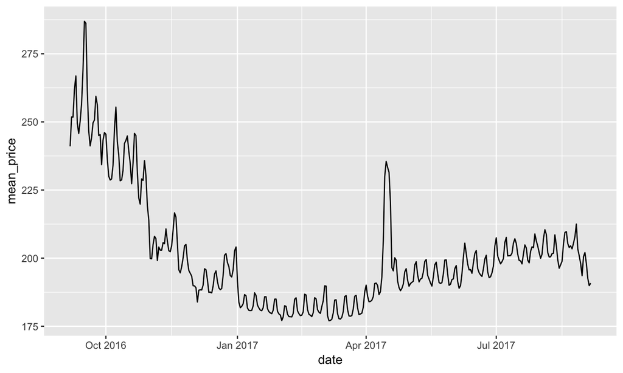

```r
 average_price_table %>%
    ggplot() +
    aes(x = date, y = mean_price) +
    geom_line()
```

## Exercise 7

Using the `summary_table` object you created earlier, make a bar chart showing the number of **apartments** by neighbourhood. In this case, the correct `geom` to use is `geom_bar(stat = 'identity')`.

## Exercise 7 Sample Solution

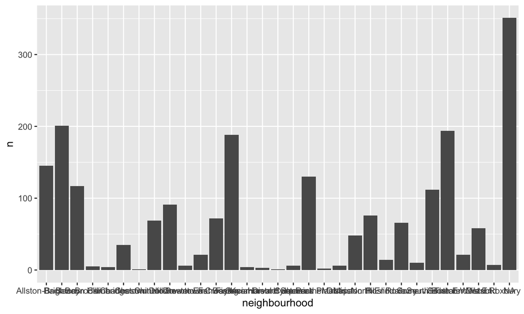

```r
summary_table %>%
    filter(property_type == 'Apartment') %>%
    ggplot() +
    aes(x = neighbourhood, y= n) +
    geom_bar(stat = 'identity')
```

## Let's Clean This Up a Bit

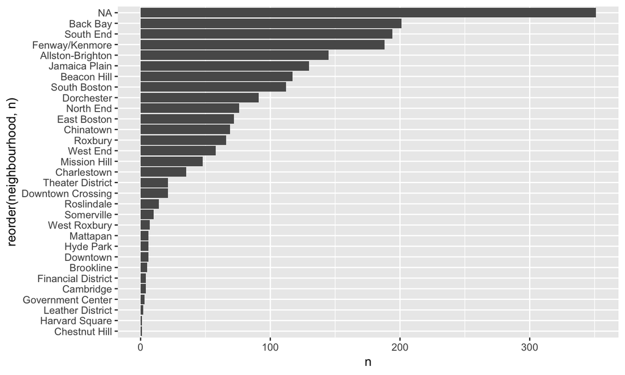

```r
summary_table %>%
    filter(property_type == 'Apartment') %>%
    ggplot() +
    aes(x = reorder(neighbourhood, n), y=n) +
    coord_flip() +
    geom_bar(stat = 'identity')
```

## Comparisons: Fill, Color, and Facets

## From Exercise 7

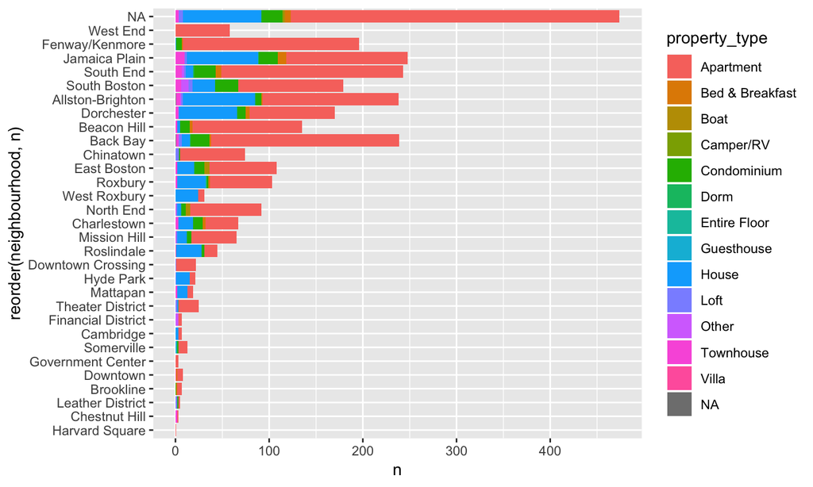

```r
summary_table %>%
    ggplot() +
    aes(x = reorder(neighbourhood, n), y=n, fill = property_type) +
    coord_flip() +
    geom_bar(stat = 'identity')
```

## From Our First Plot

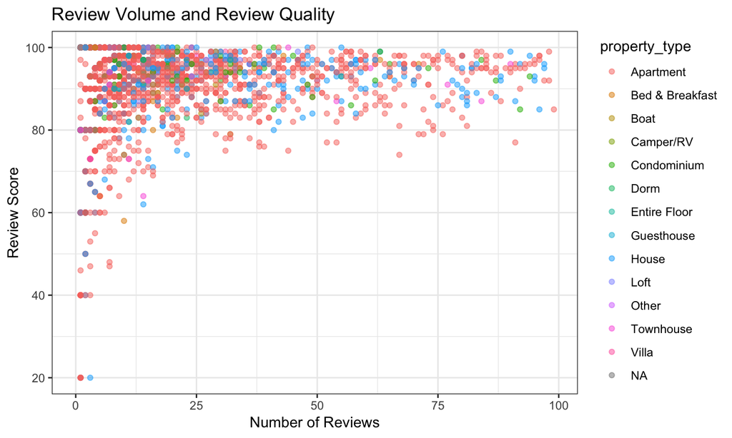

```r
listings %>%
    filter(number_of_reviews < 100) %>%
    ggplot() +
    aes(x = number_of_reviews, y = review_scores_rating, color = property_type) +
    geom_point(alpha = .5) +
    theme_bw() +
    labs(x='Number of Reviews', y='Review Score', title='Review Volume and Review Quality')
```

## From Our First Plot

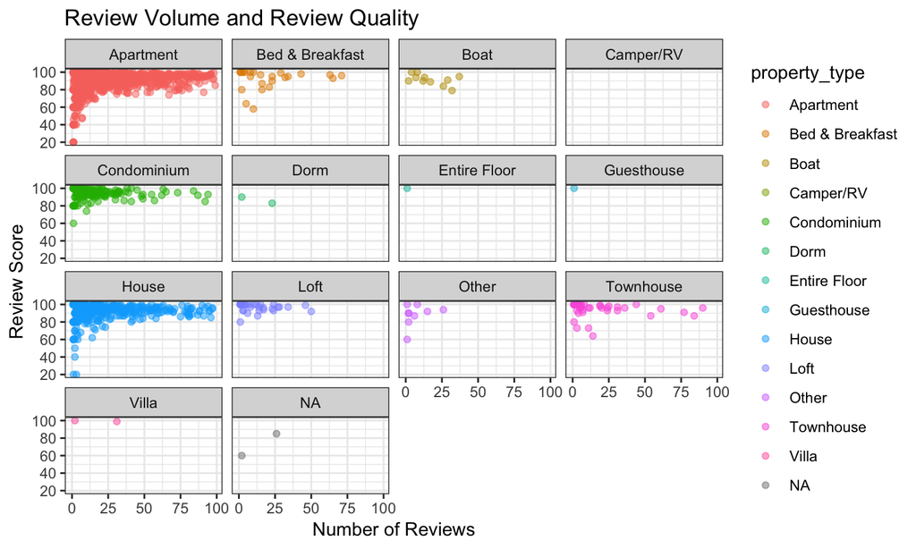

```r
listings %>%
    filter(number_of_reviews < 100) %>%
    ggplot() +
    aes(x = number_of_reviews, y = review_scores_rating, color = property_type) +
    geom_point(alpha = .5) +
    theme_bw() +
    facet_wrap(~property_type) +
    labs(x='Number of Reviews', y='Review Score', title='Review Volume and Review Quality')
```

## Mini-Project

## Project Description

- Working with your partner, you are going to make a business intelligence (BI) dashboard for AirBnB, using the EDA skills we have developed in this session.
- You will use this dashboard to lead a meeting with decision-makers on where to prioritize host recruitment efforts.
- It will look like [this](https://philchodrow.github.io/mban_orientation/data_science_intro/wrangle_viz/dashboard.html) – but better!

## Instructions

1. Open `wrangle_viz/dashboard.Rmd`
2. Click the `knit` button at the top of RStudio and observe the result. If you see a dashboard, then are good to go.
3. Modify the dashboard:
   - Include your names in the `author` metadata up top
   - Write code for data preparation and visualizations.
   - Include all your code in the `R` "code chunks" that begin with ````{r}`
   - Add commentary in the indicated area
   - `knit` your dashboard again. Save the `.Rmd` file. We're coming back to it this afternoon!
4. **FILL OUT [FEEDBACK SURVEY](https://goo.gl/forms/7rqAPMn37DzRqWko2)**
5. **Resources:** Data wrangling [cheatsheet](https://www.rstudio.com/wp-content/uploads/2015/02/data-wrangling-cheatsheet.pdf), `R` graphics [cheatsheet](https://www.rstudio.com/wp-content/uploads/2015/03/ggplot2-cheatsheet.pdf), [`R` Graphics Cookbook](http://www.cookbook-r.com/Graphs/)

## Additional Resources

## Map of the Tidyverse

[figure not shown]

## Guides and Cheatsheets

- Data Wrangling [Cheatsheet](https://www.rstudio.com/wp-content/uploads/2015/02/data-wrangling-cheatsheet.pdf)
- `ggplot2` [Cheatsheet](https://www.rstudio.com/wp-content/uploads/2015/03/ggplot2-cheatsheet.pdf)
- [The `R` Graphics Cookbook](http://www.cookbook-r.com/Graphs/), by Winston Chang

## Books and Courses

- Jenny Bryan's fabulous [course website](http://stat545.com/) on introductory, reproducible data analysis with `R`
- [R for Data Science](http://r4ds.had.co.nz/), a book on the Tidyverse by Hadley Wickham and Garrett Grolemund
- Modules 2-4 of ["Computing in Optimization and Statistics"](https://philchodrow.github.io/cos_2018/) (15.S60) covers similar material in more breadth and depth.

## Other Topics in `R`

- [Reproducible research](https://simplystatistics.org/2015/12/11/instead-of-research-on-reproducibility-just-do-reproducible-research/) with [RMarkdown](http://rmarkdown.rstudio.com/)
- Interactive data applications with [Shiny](https://shiny.rstudio.com/)
- Automate long data science pipelines with GNU [make](http://stat545.com/automation04_make-activity.html)
- Develop your own `R` [packages](http://r-pkgs.had.co.nz/)
- Some news on [`R`](https://www.r-bloggers.com/), [statistics](https://simplystatistics.org/), and [data science at FiveThirtyEight](http://fivethirtyeight.com/) (they use `R`!)